# Part I - Prosper Dataset Exploration

### Term

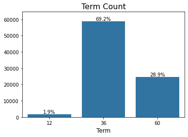

```python
ax = sb.countplot(data=df_final, x='Term', color=colour)

total = len(df_final['Term'])

for p in ax.patches:
    percentage = '{:.1f}%'.format(100 * p.get_height() / total)
    x = p.get_x() + p.get_width() / 2
    y = p.get_y() + p.get_height() + 0.5
    ax.annotate(percentage, (x, y), va='bottom', ha='center')
    plt.ylim(0, y.max()+40000)

plt.title('Term Count', fontdict={'size': 16})
plt.ylabel('', fontdict={'size': 12})
plt.xlabel('Term', fontdict={'size': 12})

plt.show()
```

> **Remark:** The Term for most loans is the 36month period followed by 60months and 12months being the least.

### Employment Status

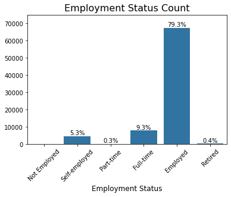

```python
ax = sb.countplot(data=df_final, x='EmploymentStatus', color=colour)
plt.xticks(rotation=45);

total = len(df_final['EmploymentStatus'])
for p in ax.patches:
    percentage = '{:.1f}%'.format(100 * p.get_height() / total)
    x = p.get_x() + p.get_width() / 2
    y = p.get_y() + p.get_height() + 0.5
    ax.annotate(percentage, (x, y), va='bottom', ha='center')
    plt.ylim([0,75000])

    plt.title('Employment Status Count', fontdict={'size': 16})
    plt.ylabel('', fontdict={'size': 12})
    plt.xlabel('Employment Status', fontdict={'size': 12})

plt.show()
```

> **Remark:** Most people taking the loans are Employed.

### Occupation

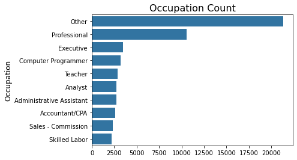

```python
# Get the top 10 occupation and plot a countplot with the defined function
top_occupation = df_final.Occupation.value_counts()[:10].index
countplot_ychart(value='Occupation', value_order=top_occupation, plot_title='Occupation Count', y_label='Occupation')
```

> **Remark:** The Chart shows the top 10 of the 68 recorded occupations.

### Listing Category

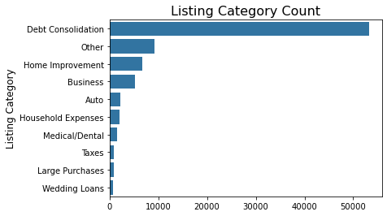

```python
# Get the top 10 listing category and plot a countplot with the defined function
top_listing = df_final.ListingCategory.value_counts()[:10].index
countplot_ychart(value='ListingCategory', value_order=top_listing, plot_title='Listing Category Count', y_label='Listing Category')
```

> **Remark:** The top Listing Category for loans is Debit Consolidation.

### ProsperScore

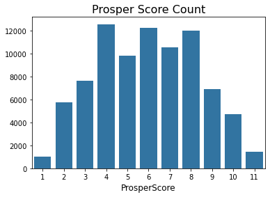

```python
countplot_xchart(value='ProsperScore', plot_title='Prosper Score Count', x_label='ProsperScore')
```

> **Remark:** Most people have a prosper score between 4 and 8.

### Income Range

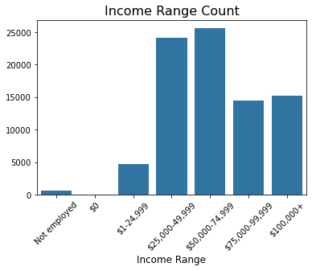

```python
countplot_xchart(value='IncomeRange', plot_title='Income Range Count', x_label='Income Range')
plt.xticks(rotation=45);
```

> **Remark:** The chart shows most people are within the income range of about `$`50,000 - `$`74,999.

### Debit To Income Ratio

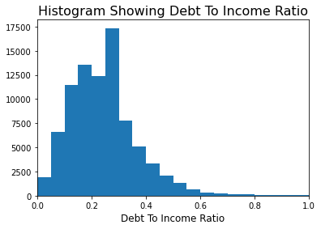

```python
histogram_chart(value='DebtToIncomeRatio', plot_title='Histogram Showing Debt To Income Ratio', bins=200, x_label='Debt To Income Ratio')
plt.xlim([0,1]);
```

> **Remark:** Debit To Income Ratio represents the balance between ones income and debt, with a higher value meaning a poor balance and a lower value meaning a better balance. The chart highlights that most people have a debt to income ratio of around 0.3.

### Average Credit Score

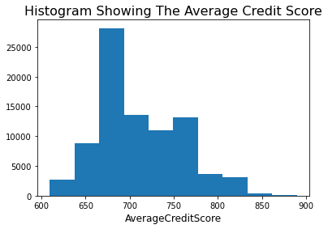

```python
histogram_chart(value='AverageCreditScore', plot_title='Histogram Showing The Average Credit Score', x_label='AverageCreditScore')
```

> **Remark:** The Average Credit Score of most people seems to be around 670 - 690.

### Loan Original Amount

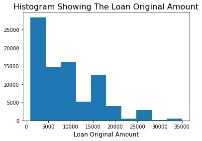

```python
histogram_chart(value='LoanOriginalAmount', plot_title='Histogram Showing The Loan Original Amount', x_label='Loan Original Amount')
```

## Bivariate Exploration

> In this section, I investigate the relationship between pairs of variables.

```python
numeric_vars = ['Term', 'BorrowerAPR', 'BorrowerRate', 'ProsperScore', 'CurrentCreditLines', 'DebtToIncomeRatio',
               'LoanOriginalAmount', 'AverageCreditScore', 'StatedMonthlyIncome', 'Recommendations']

categoric_vars = ['EmploymentStatus', 'IncomeRange', 'LoanStatus', 'LCmonth', 'LCyear']
```

### Heatmap

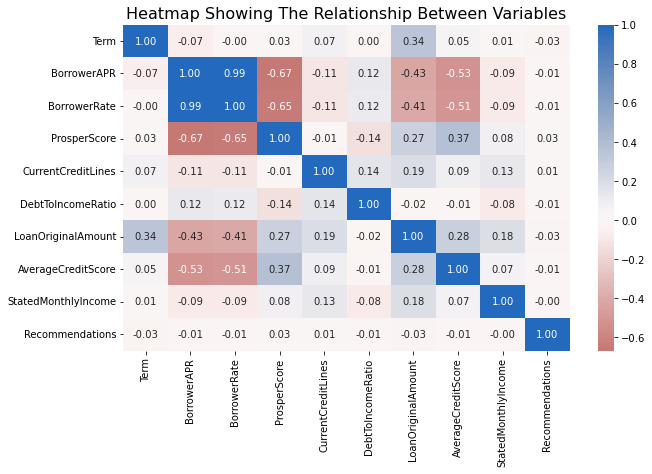

```python
# correlation plot
plt.figure(figsize = [10, 6])
sb.heatmap(df_final[numeric_vars].corr(), annot = True, fmt = '.2f',
           cmap = 'vlag_r', center = 0)

plt.title('Heatmap Showing The Relationship Between Variables', fontdict={'size': 16})
plt.show()
```

> **Remark:**
> - Correlation shows the relationship between variables. Positive correlation means both variables increase at the same time and negative correlation means as one increases, the other decreases.
> - The heat map shows a strong positive correlation between BorrowerAPR and BorrowerRate while also highlighting the positive correlations between ProsperScore and AverageCreditScore, Term and LoanOriginalAmount and LoanOriginalAmount and AverageCreditScore.
> - There are also negative correlations with the largest being between ProsperScore and BorrowerAPR.

```python
# Create a smaller random sample from the data for easy plotting.
samples = np.random.choice(df.shape[0], 1000, replace = False)
df_samp = df.loc[samples,:]
```

```python
df_samp.shape
```

```
(1000, 84)
```

```python
df_samp[numeric_vars].info()
```

```
<class 'pandas.core.frame.DataFrame'>
Int64Index: 1000 entries, 73844 to 39215
Data columns (total 10 columns):
 #   Column               Non-Null Count  Dtype
---  ------               --------------  -----
 0   Term                 1000 non-null   int64
 1   BorrowerAPR          1000 non-null   float64
 2   BorrowerRate         1000 non-null   float64
 3   ProsperScore         1000 non-null   int64
 4   CurrentCreditLines   1000 non-null   float64
 5   DebtToIncomeRatio    1000 non-null   float64
 6   LoanOriginalAmount   1000 non-null   int64
 7   AverageCreditScore   1000 non-null   float64
 8   StatedMonthlyIncome  1000 non-null   float64
 9   Recommendations      1000 non-null   int64
dtypes: float64(6), int64(4)
memory usage: 85.9 KB
```

```python
numeric_vars_small = ['ProsperScore', 'BorrowerAPR', 'BorrowerRate', 'CurrentCreditLines', 'DebtToIncomeRatio',
                        'LoanOriginalAmount', 'StatedMonthlyIncome']
```

### PairGrid Showing The Relationship Between Select Variables

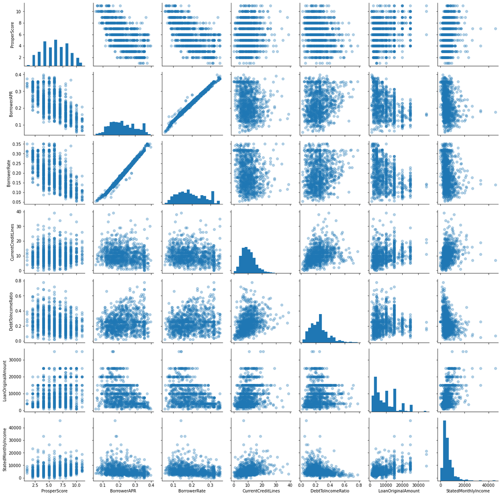

```python
g = sb.PairGrid(df_samp, vars = numeric_vars_small)

g = g.map_diag(plt.hist, bins = 20);
g.map_offdiag(plt.scatter, alpha = 1/3)

# plt.title('PairGrid Showing The Relationship Between Select Variables');
```

> **Remark:**
> - The chart goes to further highlight and visualize the relationships in the Heatmap above.

```python
numeric_vars_smaller = ['ProsperScore', 'BorrowerRate', 'LoanOriginalAmount']

categoric_vars_smaller = ['EmploymentStatus', 'IncomeRange', 'LoanStatus', 'LCyear']
```